# COVID-19 Impact on Student Academic Performance

## Andrew Hong CMSC320

### Introduction

The COVID-19 pandemic has and continues to devastate the world economically and socially, causing everyone's every way of life to change drastically. Like many other students, my classes were held virtually for the past year due to the virus.

There are many complaints from students and teachers stating how the pandemic has negatively impacted academic performance. Today, I want to investigate whether of not this is *statistically* true: was there a significant drop in academic performance during the COVID-19 pandemic?

Why are we doing this? COVID-19 has devastated many students academically, physically, and mentally. Being able to identify specific traits or variables that exacerbate these devastations will allow appropriate government/group action to combat these issues.

First we need to import some libraries that will be useful for our analysis. Information for the important libraries can be found at the bottom of the page.

```python
import pandas as pd
import csv
import numpy as np
import datetime
import matplotlib.pyplot as plt
from sklearn import linear_model
from scipy import stats
from scipy.stats import pearsonr
```

## Data Collection

### Who's the test group?

Due to the time restraint of this course and number of students, I am unfortunately unable to obtain the data from every single student. Therefore, I restricted my population to K-12 students in the state of Maryland. Along with this, I collected data from each county instead of a cumulative measurement. This is because the circumstances in each county are vastly different.

### How do we define academic performance?

There's no one perfect way of measuring academic performance as the term is very general. Normally, I would obtain test results from the MAP test, a state-wide assessment given to every student anually. However, due to the pandemic, standardized tests were cancelled for 2020/2021, making this option unavailable.

Instead, I obtained data on the number of students failing a course. More people failing indicates overall worsened academic performance and vice-versa.

### What data are we using?

Sadly, there is no one dataset that contains everything we need. However, using the power of DataFrames, we can concatenate data from multiple sources. There are 3 main pieces of information I need: number of students failing a course, COVID cases, and demographic data.

**Students Failing a Course**  
The number of student failing was obtained from a report from the Maryland Department of Education. This document was published [here](https://www.scribd.com/document/499981747/Maryland-Schools-Second-Term-Performance-Metrics-2020-2021) by WJZ, a local news station. I converted the table into a .csv file and imported it to jupyter.

**Covid Cases by County**  
The number of COVID cases was obtained from a public database published by the state of Maryland. The specific table can be found [here](https://opendata.maryland.gov/Health-and-Human-Services/MD-COVID-19-Cases-by-County/tm86-dujs). The information was able to be exported as a .csv file beautifully.

**Demographics by County**  
To gain more insight into the data for any trends, I also wanted to obtain demographic data for each county. I found a table online that provides population information for each county The specific table can be found [here](https://worldpopulationreview.com/us-counties/states/md). The information was able to be exported as a .csv file.

Another table was found here [here](http://marylandpublicschools.org/about/Documents/DCAA/SSP/20202021Student/2021EnrollRelease.pdf) . This contains information such as the number of students per county, and ethnicity breakdowns. This was published by the Maryland Department of Education. I converted the table into a .csv file and imported it to jupyter.

Links to the .csv files used are at the bottom of the page

## Data Processing

### Importing and organizing the data

Import the data from the .csv files

```python
# table of school stats
school_stats_source = pd.read_csv('school_stats_.csv')
# table of covid cases
covid_cases = pd.read_csv('covid_cases.csv')
# table of population for each county
population = pd.read_csv('mdpop.csv')
# table of student demographics dfor each county
enrollment = pd.read_csv('Enrollment.csv')
# table of incomes
income = pd.read_csv('income.csv')
```

Now that we've imported all of the data. Let's display all of the information just to make sure we've imported all of it properly. Calling .head() will display only the top 5 rows.

```python
school_stats_source.head()
```

|  | Reporting Area | Definition | Allegany | Anne\nArundel | Baltimore City | Baltimore\nCounty | Calvert | Caroline | Carroll | Cecil | ... | Kent | Montgomery | Prince\nGeorge's | Queen Anne's | Somerset | St. Mary's | Talbot | Washington | Wicomico | Worcester |
| --- | --- | --- | --- | --- | --- | --- | --- | --- | --- | --- | --- | --- | --- | --- | --- | --- | --- | --- | --- | --- | --- |
| 0 | Second Term Dates | Start Date | 11/13/2020 | 11/16/2020 | 11/12/2020 | 11/16/2020 | 11/10/2020 | 11/11/2020 | 11/12/2020 | 11/10/2020 | ... | 11/11/2020 | 11/10/2021 | 11/06/2020 | 11/04/2020 | 11/16/2020 | 11/02/2020 | 11/09/2020 | 11/03/2020 | 11/11/2020 | 11/16/2020 |
| 1 | NaN | End Date | 02/01/2021 | 01/29/2021 | 01/27/2021 | 01/29/2021 | 01/28/2021 | 01/28/2021 | 01/29/2021 | 01/27/2021 | ... | 01/28/2021 | 01/29/2021 | 01/27/2021 | 01/25/2021 | 02/04/2021 | 01/22/2021 | 01/28/2021 | 01/22/2021 | 01/29/2021 | 01/29/2021 |
| 2 | Outbreaks and Closures | # of buildings closed due to COVID on the last... | 21 | 125 | 0 | 174 | 0 | 0 | 0 | 0 | ... | 0 | 0 | 0 | All | 9 | 28 | 0 | All | All | 0 |
| 3 | NaN | # of COVID outbreaks among\nstudents | 0 | 0 | 0 | 0 | 0 | 0 | 2 | 0 | ... | 0 | Unknown | 0 | 0 | 0 | 0 | 0 | 1 | 0 | 0 |
| 4 | NaN | # of COVID outbreaks among staff | 0 | 0 | 1 | 0 | 1 | 0 | 4 | 0 | ... | 0 | 0 | 0 | 0 | 0 | 0 | 0 | 1 | 1 | 0 |

5 rows × 26 columns

```python
covid_cases.head()
```

|  | OBJECTID | DATE | Allegany | Anne_Arundel | Baltimore | Baltimore_City | Calvert | Caroline | Carroll | Cecil | ... | Montgomery | Prince_Georges | Queen_Annes | Somerset | St_Marys | Talbot | Washington | Wicomico | Worcester | Unknown |
| --- | --- | --- | --- | --- | --- | --- | --- | --- | --- | --- | --- | --- | --- | --- | --- | --- | --- | --- | --- | --- | --- |
| 0 | 1 | 03/15/2020 10:00:00 AM | NaN | 2 | 3 | 1 | NaN | NaN | 1 | NaN | ... | 12 | 9 | NaN | NaN | NaN | NaN | NaN | NaN | NaN | NaN |
| 1 | 2 | 03/16/2020 10:00:00 AM | NaN | 1 | 4 | 1 | NaN | NaN | 1 | NaN | ... | 10 | 15 | NaN | NaN | NaN | 1.0 | NaN | NaN | NaN | NaN |
| 2 | 3 | 03/17/2020 10:00:00 AM | NaN | 3 | 6 | 1 | NaN | NaN | 1 | NaN | ... | 24 | 14 | NaN | NaN | NaN | 1.0 | NaN | NaN | NaN | NaN |
| 3 | 4 | 03/18/2020 10:00:00 AM | NaN | 4 | 10 | 4 | NaN | NaN | 1 | NaN | ... | 31 | 20 | NaN | NaN | NaN | 1.0 | NaN | NaN | NaN | NaN |
| 4 | 5 | 03/19/2020 10:00:00 AM | NaN | 5 | 12 | 8 | 1.0 | NaN | 2 | NaN | ... | 33 | 23 | NaN | NaN | NaN | 1.0 | NaN | NaN | NaN | NaN |

5 rows × 27 columns

```python
population.head()
```

|  | CTYNAME | pop2021 | GrowthRate | popDensity |
| --- | --- | --- | --- | --- |
| 0 | Montgomery County | 1055110 | 8.1496 | 2543.1341 |
| 1 | Prince George's County | 908743 | 4.8849 | 2190.3454 |
| 2 | Baltimore County | 826392 | 2.4466 | 1991.8546 |
| 3 | Anne Arundel County | 586656 | 8.7842 | 1414.0183 |
| 4 | Baltimore City County | 575584 | -7.3007 | 1387.3315 |

```python
enrollment.head()
```

|  | Table 1 | Unnamed: 1 | Unnamed: 2 | Unnamed: 3 | Unnamed: 4 | Unnamed: 5 | Unnamed: 6 | Unnamed: 7 | Unnamed: 8 | Unnamed: 9 | Unnamed: 10 | Unnamed: 11 | Unnamed: 12 | Unnamed: 13 | Unnamed: 14 | Unnamed: 15 |
| --- | --- | --- | --- | --- | --- | --- | --- | --- | --- | --- | --- | --- | --- | --- | --- | --- |
| 0 | Enrollment in Maryland Public Schools by Race/... | NaN | NaN | NaN | NaN | NaN | NaN | NaN | NaN | NaN | NaN | NaN | NaN | NaN | NaN | NaN |
| 1 | Local School\nSystem | Total\nStudents | American\nIndian/\nAlaska\nNative\nNumber | American\nIndian/\nAlaska\nNative\nPercent | Asian\nNumber | Asian\nPercent | Black/\nAfrican\nAmerican\nNumber | Black/\nAfrican\nAmerican\nPercent | White\nNumber | White\nPercent | Hispanic\nNumber | Hispanic\nPercent | Native\nHawaiian/\nOther\nPacific\nIslander\nN... | Native\nHawaiian/\nOther\nPacific\nIslander\nP... | Two or\nMore\nRaces\nNumber | Two or\nMore\nRaces\nPercent |
| 2 | Total State | 882,538 | 2,286 | 0.3 | 59,668 | 6.8 | 295,736 | 33.5 | 304,212 | 34.5 | 175,768 | 19.9 | 1,287 | 0.1 | 43,581 | 4.9 |
| 3 | Allegany | 8,075 | 12 | 0.1 | 72 | 0.9 | 290 | 3.6 | 6,990 | 86.6 | 140 | 1.7 | 6 | 0.1 | 565 | 7.0 |
| 4 | Anne Arundel | 83,044 | 229 | 0.3 | 3,286 | 4.0 | 17,896 | 21.6 | 41,289 | 49.7 | 14,935 | 18.0 | 169 | 0.2 | 5,240 | 6.3 |

```python
income.head()
```

|  | County | Total Population, 2018 | Total Population, 2010 | Total Population, 2000 | Population Change, 2000-2010 | Population Density per Square Mile | Median Age | Per Capita Personal Income ($ Dollars) | Median Household Income ($ Dollars) | Total Personal Income ($ Thousands) |
| --- | --- | --- | --- | --- | --- | --- | --- | --- | --- | --- |
| 0 | Allegany County | 70975 | 75087 | 74909 | 178 | 177 | 41.4 | 40517 | 43535 | 2875729 |
| 1 | Anne Arundel County | 576031 | 537656 | 489677 | 47979 | 1295.9 | 38.4 | 67363 | 97051 | 38803403 |
| 2 | Baltimore City | 602495 | 620961 | 651262 | -30301 | 7671.5 | 35.6 | 51357 | 50501 | 30942036 |
| 3 | Baltimore County | 828431 | 805029 | 753947 | 51082 | 1345.5 | 39.5 | 61556 | 75836 | 50994500 |
| 4 | Calvert County | 92003 | 88737 | 74556 | 14181 | 416.3 | 40.5 | 62591 | 106270 | 5758531 |

Woah. Some of the formatting of these DataFrames is messed up. Let's clean it up a bit.

### Fixing the Enrollment and Population DataFrames

```python
# get column names
enrollment_columns = enrollment.iloc[1].tolist()
# remove any unecessary characters
for i in range(len(enrollment_columns)):
    enrollment_columns[i] = enrollment_columns[i].replace('\n', '_').replace('/', '').replace(' ', '_')
# remove unecessary columns
enrollment = enrollment.iloc[3:28, :]
# rename columns
enrollment.columns = enrollment_columns
enrollment.head()
```

|  | Local_School_System | Total_Students | American_Indian_Alaska_Native_Number | American_Indian_Alaska_Native_Percent | Asian_Number | Asian_Percent | Black_African_American_Number | Black_African_American_Percent | White_Number | White_Percent | Hispanic_Number | Hispanic_Percent | Native_Hawaiian_Other_Pacific_Islander_Number | Native_Hawaiian_Other_Pacific_Islander_Percent | Two_or_More_Races_Number | Two_or_More_Races_Percent |
| --- | --- | --- | --- | --- | --- | --- | --- | --- | --- | --- | --- | --- | --- | --- | --- | --- |
| 3 | Allegany | 8,075 | 12 | 0.1 | 72 | 0.9 | 290 | 3.6 | 6,990 | 86.6 | 140 | 1.7 | 6 | 0.1 | 565 | 7.0 |
| 4 | Anne Arundel | 83,044 | 229 | 0.3 | 3,286 | 4.0 | 17,896 | 21.6 | 41,289 | 49.7 | 14,935 | 18.0 | 169 | 0.2 | 5,240 | 6.3 |
| 5 | Baltimore City | 77,856 | 162 | 0.2 | 644 | 0.8 | 58,940 | 75.7 | 5,868 | 7.5 | 11,093 | 14.2 | 112 | 0.1 | 1,037 | 1.3 |
| 6 | Baltimore | 111,084 | 467 | 0.4 | 8,059 | 7.3 | 44,565 | 40.1 | 38,373 | 34.5 | 13,827 | 12.4 | 148 | 0.1 | 5,645 | 5.1 |
| 7 | Calvert | 15,292 | 32 | 0.2 | 232 | 1.5 | 2,056 | 13.4 | 10,495 | 68.6 | 1,027 | 6.7 | 14 | 0.1 | 1,436 | 9.4 |

There! Looks much better.

### Why so many DataFrames?

All of the data we need is not in one table sadly :(. However, with the power of DataFrames, we can join them together. In order to do this properly, the formatting of the county names needs to be the same. This is how they were formatted:

Remove any spaces

Remove punctuation

CamelCase

In order to match information properly for each county, I created a function that removes any punctuation and unnecessary words from the county name.

```python
# edit county names for population
def edit_names_population(row):
    # remove county
    row.CTYNAME = row.CTYNAME.replace('County', '')
    # remove period
    row.CTYNAME = row.CTYNAME.replace(' ', '')
    # remove ''
    row.CTYNAME = row.CTYNAME.replace('\'', '')
    # remove .
    row.CTYNAME = row.CTYNAME.replace('.', '')
    return row.CTYNAME

# edit county names for enrollment
def edit_names_enrollment(row):
    # remove period
    row.Local_School_System = row.Local_School_System.replace(' ', '')
    # remove ''
    row.Local_School_System = row.Local_School_System.replace('\'', '')
    # remove .
    row.Local_School_System = row.Local_School_System.replace('.', '')
    row.Local_School_System = row.Local_School_System.replace('Saint', 'St')
    # remove , in order to cast to float
    row.Total_Students = row.Total_Students.replace(',', '')
    return row.Local_School_System
```

Using the .apply() method will allow us to modify each of the rows of the DataFrame in a concise manner. The lambda function allows us to call the functions that we wrote up previously.

```python
# edit CTYNAME column using new method created
population['CTYNAME'] = population.apply(lambda row: edit_names_population(row), axis = 1)
# edit Local_School_System column using new method created
enrollment['Local_School_System'] = enrollment.apply(lambda row: edit_names_enrollment(row), axis = 1)
```

```python
enrollment.head()
```

|  | Local_School_System | Total_Students | American_Indian_Alaska_Native_Number | American_Indian_Alaska_Native_Percent | Asian_Number | Asian_Percent | Black_African_American_Number | Black_African_American_Percent | White_Number | White_Percent | Hispanic_Number | Hispanic_Percent | Native_Hawaiian_Other_Pacific_Islander_Number | Native_Hawaiian_Other_Pacific_Islander_Percent | Two_or_More_Races_Number | Two_or_More_Races_Percent |
| --- | --- | --- | --- | --- | --- | --- | --- | --- | --- | --- | --- | --- | --- | --- | --- | --- |
| 3 | Allegany | 8075 | 12 | 0.1 | 72 | 0.9 | 290 | 3.6 | 6,990 | 86.6 | 140 | 1.7 | 6 | 0.1 | 565 | 7.0 |
| 4 | AnneArundel | 83044 | 229 | 0.3 | 3,286 | 4.0 | 17,896 | 21.6 | 41,289 | 49.7 | 14,935 | 18.0 | 169 | 0.2 | 5,240 | 6.3 |
| 5 | BaltimoreCity | 77856 | 162 | 0.2 | 644 | 0.8 | 58,940 | 75.7 | 5,868 | 7.5 | 11,093 | 14.2 | 112 | 0.1 | 1,037 | 1.3 |
| 6 | Baltimore | 111084 | 467 | 0.4 | 8,059 | 7.3 | 44,565 | 40.1 | 38,373 | 34.5 | 13,827 | 12.4 | 148 | 0.1 | 5,645 | 5.1 |
| 7 | Calvert | 15292 | 32 | 0.2 | 232 | 1.5 | 2,056 | 13.4 | 10,495 | 68.6 | 1,027 | 6.7 | 14 | 0.1 | 1,436 | 9.4 |

```python
population.head()
```

|  | CTYNAME | pop2021 | GrowthRate | popDensity |
| --- | --- | --- | --- | --- |
| 0 | Montgomery | 1055110 | 8.1496 | 2543.1341 |
| 1 | PrinceGeorges | 908743 | 4.8849 | 2190.3454 |
| 2 | Baltimore | 826392 | 2.4466 | 1991.8546 |
| 3 | AnneArundel | 586656 | 8.7842 | 1414.0183 |
| 4 | BaltimoreCity | 575584 | -7.3007 | 1387.3315 |

### Fixing the School_Stats_Source DataFrame

There were a lot of issues with this table. The first main issue was that the county names were used as column names, making it difficult to mesh with the other dataframes. To fix this issue, I transposed the dataframe and renamed the columns.

I also removed unnecessary columns ('Reporting Area') and replaced any 'Unknown' entries as np.nan. Unknown is not able to be recognized as an empty entry. I suspect the information is missing due to lack of resources/time/communication and not an act of negliglance or some other external factor as COVID cases for other days were able to be obtained.

```python
# remove reporing area column
school_stats_source = school_stats_source.drop(columns=['Reporting Area'])
# transpose
school_stats_source = school_stats_source.transpose()
# replace unknown with NaN for easier analysis
school_stats_source = school_stats_source.replace('Unknown', np.nan)
school_stats_source
```

|  | 0 | 1 | 2 | 3 | 4 | 5 | 6 | 7 | 8 | 9 | ... | 113 | 114 | 115 | 116 | 117 | 118 | 119 | 120 | 121 | 122 |
| --- | --- | --- | --- | --- | --- | --- | --- | --- | --- | --- | --- | --- | --- | --- | --- | --- | --- | --- | --- | --- | --- |
| Definition | Start Date | End Date | # of buildings closed due to COVID on the last... | # of COVID outbreaks among\nstudents | # of COVID outbreaks among staff | % of schools where teacher and student were ph... | % of students in fully face-to-face, in-\npers... | % of students in hybrid instruction | % students fully in virtual instruction | Other learning model | ... | Black/African-American | Hispanic/Latino | Two or More Races/Ethnicities | Pacific Islander | White | Students with Disabilities | English Learners | Economically Disadvantaged | Male | Female |
| Allegany | 11/13/2020 | 02/01/2021 | 21 | 0 | 0 | 0% | 0% | 0% | 100% | 0% | ... | NaN | NaN | NaN | NaN | NaN | NaN | NaN | NaN | NaN | NaN |
| Anne\nArundel | 11/16/2020 | 01/29/2021 | 125 | 0 | 0 | 0.8% | 0% | 0.01% | 99.99% | 0% | ... | 91.9 | 90.9 | 93.6 | 97 | 90.8 | 76.9 | 90.4 | 82.5 | 90 | 94 |
| Baltimore City | 11/12/2020 | 01/27/2021 | 0 | 0 | 1 | 23.30% | 0% | 0.9% | 99.1% | 0% | ... | 84.2 | 88.1 | 89.7 | 88 | 91.8 | 80.6 | 87 | 82.9 | 85 | 86.5 |
| Baltimore\nCounty | 11/16/2020 | 01/29/2021 | 174 | 0 | 0 | 0% | 0% | 0% | 100% | 0% | ... | 68.6 | 72.6 | 64.9 | 88.6 | 70.1 | 74 | 78.6 | 65.6 | 71.5 | 69.2 |
| Calvert | 11/10/2020 | 01/28/2021 | 0 | 0 | 1 | 0% | 0% | 0% | 100% | 0% | ... | 72.7 | NaN | 65.8 | NaN | 89.2 | 80.5 | NaN | 73.9 | 82.5 | 74.7 |
| Caroline | 11/11/2020 | 01/28/2021 | 0 | 0 | 0 | 100% | 1% | 0% | 99% | 0% | ... | NaN | NaN | NaN | NaN | NaN | NaN | NaN | NaN | NaN | NaN |
| Carroll | 11/12/2020 | 01/29/2021 | 0 | 2 | 4 | 100% | 0% | 57.40% | 41.60% | 0% | ... | 98 | 68 | 0 | 0 | 93 | 91 | 0 | 96 | 89 | 95 |
| Cecil | 11/10/2020 | 01/27/2021 | 0 | 0 | 0 | 100% | 5% | 0% | 95% | 0% | ... | NaN | NaN | NaN | NaN | NaN | NaN | NaN | NaN | NaN | NaN |
| Charles | 11/04/2020 | 01/27/2021 | 0 | 0 | 4 | 0% | 0% | 0% | 100% | 0% | ... | NaN | NaN | NaN | NaN | NaN | NaN | NaN | NaN | NaN | NaN |
| Dorchester | 11/04/2020 | 01/26/2021 | 12 | 0 | 0 | 0% | 0% | 0% | 100% | 0% | ... | 94.5 | 97.8 | 93.9 | NaN | 95.8 | 95.7 | 100 | 95.8 | 95.9 | 95.7 |
| Frederick | 11/10/2020 | 01/26/2021 | 0 | 2 | 5 | 34% | 0% | 0% | 99.8% | 0.2% (hub) | ... | 99.2 | 98.9 | 99.2 | 100 | 99.4 | 96.7 | 100 | 98.4 | 99.3 | 99.3 |
| Garrett | 11/11/2020 | 01/26/2021 | 12 | 0 | 1 | 0% | 0% | 0% | 100% | 0% | ... | NaN | NaN | NaN | NaN | 99.39 | NaN | NaN | 98.49 | 99.24 | 99.74 |
| Harford | 11/09/2020 | 01/22/2021 | 0 | 0 | 0 | 0% | 0% | 0% | 100% | 0% | ... | 76.8 | 71.6 | 76.7 | NaN | 83.4 | 81.2 | NaN | 74.1 | 82.2 | 77.8 |
| Howard | 11/09/2020 | 01/28/2021 | 0 | 2 | 1 | 0% | 0% | 0% | 100% | 0% | ... | 66.7 | 72.2 | 74.6 | NaN | 84.4 | 78.2 | NaN | 61.8 | 74.1 | 72.7 |
| Kent | 11/11/2020 | 01/28/2021 | 0 | 0 | 0 | 100% | 53.27% | 28.53% | 18.20% | 0% | ... | NaN | NaN | NaN | NaN | NaN | NaN | NaN | NaN | NaN | NaN |
| Montgomery | 11/10/2021 | 01/29/2021 | 0 | NaN | 0 | 0% | 0% | 0% | 100% | 0% | ... | 87.54 | 85.63 | 84.45 | NaN | 90.36 | 86.77 | 83.28 | 86.77 | 89.57 | 85.3 |
| Prince\nGeorge's | 11/06/2020 | 01/27/2021 | 0 | 0 | 0 | 0% | 0% | 0% | 100% | 0% | ... | 93.69 | 90.8 | 94.95 | 94.55 | 95.1 | 87.63 | 89.7 | 90.8 | 92.82 | 94.02 |
| Queen Anne's | 11/04/2020 | 01/25/2021 | All | 0 | 0 | 0% | 0% | 0% | 100% | 0% | ... | 90.77% | 87.56% | 85.22% | NaN | 91.59% | 86.44% | 82.84% | 85.66% | 89.49% | 91.5% |
| Somerset | 11/16/2020 | 02/04/2021 | 9 | 0 | 0 | 0% | 0% | 0% | 100% | 0% | ... | 90.9 | 96.4 | 88.7 | NaN | 94 | 91.6 | 97.7 | 89.7 | 91.5 | 94 |
| St. Mary's | 11/02/2020 | 01/22/2021 | 28 | 0 | 0 | 0% | 0% | 0% | 100% | 0% | ... | 94.7 | 99.33 | 98.19 | NaN | 98.32 | 97.34 | 100 | 94.23 | 97.86 | 98.28 |
| Talbot | 11/09/2020 | 01/28/2021 | 0 | 0 | 0 | 100% | 10% | 0% | 90% | 0% | ... | 98.19 | 99.86 | 100 | NaN | 99.45 | 98.29 | 100 | 98.84 | 99.31 | 99.49 |
| Washington | 11/03/2020 | 01/22/2021 | All | 1 | 1 | 0% | 0% | 0% | 100% | 0% | ... | 55.21 | NaN | 79.78 | NaN | 84.7 | 70.55 | NaN | 79.39 | 83.4 | 83.13 |
| Wicomico | 11/11/2020 | 01/29/2021 | All | 0 | 1 | 0% | 0% | 0% | 100% | 0% | ... | 93.7 | 93.5 | 95.4 | NaN | 96.5 | 94.1 | 97 | 94 | 95.5 | 96.6 |
| Worcester | 11/16/2020 | 01/29/2021 | 0 | 0 | 0 | 100% | 35.6% | 0% | 64.4% | 0% | ... | 93.25 | 94.33 | 93.03 | NaN | 94.44 | 94.3 | 95.61 | 93.81 | 94.28 | 93.84 |

25 rows × 123 columns

If you notice, a lot of these columns aren't necessary, let's cut some of them out and make a new DataFrame.  
I want to isolate only the columns that contain the number of students that failed

```python
# isolate the necessary columns
school_stats = school_stats_source.iloc[:, 21:-82]
```

```python
school_stats.head()
```

|  | 21 | 22 | 23 | 24 | 25 | 26 | 27 | 28 | 29 | 30 | 31 | 32 | 33 | 34 | 35 | 36 | 37 | 38 | 39 | 40 |
| --- | --- | --- | --- | --- | --- | --- | --- | --- | --- | --- | --- | --- | --- | --- | --- | --- | --- | --- | --- | --- |
| Definition | # of elementary students earning a failing gra... | # of elementary students earning a\nfailing gr... | # of elementary students earning a failing gra... | # of elementary students earning a failing gra... | # of middle school students earning a failing... | # of middle school students earning\na failing... | # of middle school students earning a failing... | # of middle school students earning a failing... | # of middle school students earning a failing... | # of middle school students earning a failing ... | # of middle school students earning a failing... | # of middle school students earning a failing... | # of high school students earning a failing gr... | # of high school students earning a failing gr... | # of high school students earning a failing gr... | # of high school students earning a failing gr... | # of high school students earning a failing gr... | # of high school students earning a failing gr... | # of high school students earning a failing gr... | # of high school students earning a failing gr... |
| Allegany | 77 | 83 | 15 | 15 | 319 | 331 | 389 | 334 | 115 | 122 | 80 | 105 | 509 | 566 | 406 | 280 | 193 | 257 | 195 | 170 |
| Anne\nArundel | 1506 | 1131 | 509 | 445 | 1825 | 2130 | 1829 | 1767 | 1127 | 1485 | 1346 | 1085 | 3390 | 3473 | 2840 | 2643 | 1942 | 2511 | 2210 | 1672 |
| Baltimore City | 9988 | 9303 | 4891 | 5233 | 5605 | 5794 | 5234 | 5351 | 2733 | 2880 | 2050 | 2053 | 8231 | 7257 | 5886 | 4916 | 5552 | 5246 | 3870 | 3486 |
| Baltimore\nCounty | 902 | 977 | 467 | 637 | 4867 | 5095 | 4173 | 4384 | 2681 | 2822 | 2741 | 2650 | 3742 | 4509 | 3934 | 3591 | 5407 | 6196 | 5215 | 4776 |

Using .iloc allows us to isolate specific rows and columns

```python
# rename columns
columns_names = school_stats.iloc[0].tolist()
school_stats.columns = columns_names
school_stats = school_stats.iloc[1: , :]
```

```python
school_stats.head()
```

|  | # of elementary students earning a failing grade in English in the second marking period of 2020-2021 | # of elementary students earning a\nfailing grade in Math in the second marking period of 2020-2021 | # of elementary students earning a failing grade in English in the second marking period of 2019-2020 | # of elementary students earning a failing grade in Math in the second\nmarking period of 2019-2020 | # of middle school students earning a failing grade in English in the second marking period of 2020-2021 | # of middle school students earning\na failing grade in Math in the second marking period of 2020-2021 | # of middle school students earning a failing grade in Science in the second marking period of 2020-2021 | # of middle school students earning a failing grade in Social Studies in the second marking period of 2020-2021 | # of middle school students earning a failing grade in English in the second marking period of 2019-2020 | # of middle school students earning a failing grade in Math in the second\nmarking period of 2019-2020 | # of middle school students earning a failing grade in Science in the second marking period of 2019-2020 | # of middle school students earning a failing grade in Social Studies in the second marking period of 2019-2020 | # of high school students earning a failing grade in English in the second marking period of 2020-2021 | # of high school students earning a failing grade in Math in the second\nmarking period of 2020-2021 | # of high school students earning a failing grade in Science in the second marking period of 2020-2021 | # of high school students earning a failing grade in Social Studies in the second marking period of 2020-2021 | # of high school students earning a failing grade in English in the second marking period of 2020-2021 | # of high school students earning a failing grade in Math in the second\nmarking period of 2019-2020 | # of high school students earning a failing grade in Science in the second marking period of 2019-2020 | # of high school students earning a failing grade in Social Studies in the second marking period of 2019-2020 |
| --- | --- | --- | --- | --- | --- | --- | --- | --- | --- | --- | --- | --- | --- | --- | --- | --- | --- | --- | --- | --- |
| Allegany | 77 | 83 | 15 | 15 | 319 | 331 | 389 | 334 | 115 | 122 | 80 | 105 | 509 | 566 | 406 | 280 | 193 | 257 | 195 | 170 |
| Anne\nArundel | 1506 | 1131 | 509 | 445 | 1825 | 2130 | 1829 | 1767 | 1127 | 1485 | 1346 | 1085 | 3390 | 3473 | 2840 | 2643 | 1942 | 2511 | 2210 | 1672 |
| Baltimore City | 9988 | 9303 | 4891 | 5233 | 5605 | 5794 | 5234 | 5351 | 2733 | 2880 | 2050 | 2053 | 8231 | 7257 | 5886 | 4916 | 5552 | 5246 | 3870 | 3486 |
| Baltimore\nCounty | 902 | 977 | 467 | 637 | 4867 | 5095 | 4173 | 4384 | 2681 | 2822 | 2741 | 2650 | 3742 | 4509 | 3934 | 3591 | 5407 | 6196 | 5215 | 4776 |
| Calvert | 200 | 194 | 19 | 44 | 383 | 289 | 390 | 458 | 101 | 132 | 102 | 109 | 828 | 836 | 605 | 619 | 455 | 497 | 306 | 355 |

```python
# rename columns for school_stats DataFrame
column_names = ['Elementary, English, 2021', 'Elementary, Math, 2021', \
                'Elementary, English, 2020', 'Elementary, Math, 2020', \
                'Middle, English, 2021', 'Middle, Math, 2021', \
                'Middle, Science, 2021', 'Middle, Social, 2021', \
                'Middle, English, 2020', 'Middle, Math, 2020', \
                'Middle, Science, 2020', 'Middle, Social, 2020', \
                'High, English, 2021', 'High, Math, 2021', \
                'High, Science, 2021', 'High, Social, 2021', \
                'High, English, 2020', 'High, Math, 2020', \
                'High, Science, 2020', 'High, Social, 2020']
school_stats.columns = column_names
```

### Summing the Number of Courses Failed by Students

We need to add the number of students that failed for each school year. This will be easier if we separate school_stats into two DataFrames

```python
school_stats_2021 = school_stats[['Elementary, English, 2021', 'Elementary, Math, 2021', \
                                 'Middle, English, 2021', 'Middle, Math, 2021', \
                                 'Middle, Science, 2021', 'Middle, Social, 2021', \
                                 'High, English, 2021', 'High, Math, 2021', \
                                 'High, Science, 2021', 'High, Social, 2021' ]]
school_stats_2020 = school_stats[['Elementary, English, 2020', 'Elementary, Math, 2020', \
                                  'Middle, English, 2020', 'Middle, Math, 2020', \
                                  'Middle, Science, 2020', 'Middle, Social, 2020', \
                                  'High, English, 2020', 'High, Math, 2020', \
                                  'High, Science, 2020', 'High, Social, 2020' ]]
```

```python
school_stats_2021.head()
```

|  | Elementary, English, 2021 | Elementary, Math, 2021 | Middle, English, 2021 | Middle, Math, 2021 | Middle, Science, 2021 | Middle, Social, 2021 | High, English, 2021 | High, Math, 2021 | High, Science, 2021 | High, Social, 2021 |
| --- | --- | --- | --- | --- | --- | --- | --- | --- | --- | --- |
| Allegany | 77 | 83 | 319 | 331 | 389 | 334 | 509 | 566 | 406 | 280 |
| Anne\nArundel | 1506 | 1131 | 1825 | 2130 | 1829 | 1767 | 3390 | 3473 | 2840 | 2643 |
| Baltimore City | 9988 | 9303 | 5605 | 5794 | 5234 | 5351 | 8231 | 7257 | 5886 | 4916 |
| Baltimore\nCounty | 902 | 977 | 4867 | 5095 | 4173 | 4384 | 3742 | 4509 | 3934 | 3591 |
| Calvert | 200 | 194 | 383 | 289 | 390 | 458 | 828 | 836 | 605 | 619 |

Next we need to add up all of the cases from each student. We replace any NaN values and N < 10 values with 0. It's better to assume no cases rather than any number of cases. Also, there may be the case where cases not counted on day are counted for another so treating it as something as besides 0 would lead to double-counting.

```python
# replace values
school_stats_2021 = school_stats_2021.replace(np.nan, 0)
school_stats_2021 = school_stats_2021.replace('N < 10', 0)
school_stats_2020 = school_stats_2020.replace(np.nan, 0)
school_stats_2020 = school_stats_2020.replace('N < 10', 0)

# make a new column thats total the number of failing students
school_stats_2021['Number_of_Students_Failing_Class'] = school_stats_2021.apply(lambda row: row.astype('int').sum(skipna = True), axis = 1)
school_stats_2021['Number_of_Students_Failing_Class_2020'] = school_stats_2020.apply(lambda row: row.astype('int').sum(skipna = True), axis = 1)

school_stats_2020['Number_of_Students_Failing_Class'] = school_stats_2020.apply(lambda row: row.astype('int').sum(skipna = True), axis = 1)

# change values back to NaN
school_stats_2021 = school_stats_2021.replace(0, np.nan)
school_stats_2020 = school_stats_2020.replace(0, np.nan)
```

```python
school_stats_2021.head()
```

|  | Elementary, English, 2021 | Elementary, Math, 2021 | Middle, English, 2021 | Middle, Math, 2021 | Middle, Science, 2021 | Middle, Social, 2021 | High, English, 2021 | High, Math, 2021 | High, Science, 2021 | High, Social, 2021 | Number_of_Students_Failing_Class | Number_of_Students_Failing_Class_2020 |
| --- | --- | --- | --- | --- | --- | --- | --- | --- | --- | --- | --- | --- |
| Allegany | 77 | 83 | 319 | 331 | 389 | 334 | 509 | 566 | 406 | 280 | 3294 | 1267 |
| Anne\nArundel | 1506 | 1131 | 1825 | 2130 | 1829 | 1767 | 3390 | 3473 | 2840 | 2643 | 22534 | 14332 |
| Baltimore City | 9988 | 9303 | 5605 | 5794 | 5234 | 5351 | 8231 | 7257 | 5886 | 4916 | 67565 | 37994 |
| Baltimore\nCounty | 902 | 977 | 4867 | 5095 | 4173 | 4384 | 3742 | 4509 | 3934 | 3591 | 36174 | 33592 |
| Calvert | 200 | 194 | 383 | 289 | 390 | 458 | 828 | 836 | 605 | 619 | 4802 | 2120 |

Rename the county names so that it's consistent among all the DataFrames

```python
school_stats_2021 = school_stats_2021.rename(index={'Anne\nArundel': 'AnneArundel', 'Baltimore City': 'BaltimoreCity', \
                                         'Baltimore\nCounty': 'Baltimore', 'Prince\nGeorge\'s': 'PrinceGeorges',
                                         'Queen Anne\'s': 'QueenAnnes', 'St. Mary\'s': 'StMarys'})
school_stats_2020 = school_stats_2020.rename(index={'Anne\nArundel': 'AnneArundel', 'Baltimore City': 'BaltimoreCity', \
                                         'Baltimore\nCounty': 'Baltimore', 'Prince\nGeorge\'s': 'PrinceGeorges',
                                         'Queen Anne\'s': 'QueenAnnes', 'St. Mary\'s': 'StMarys'})
```

### Fixing the Income DataFrame

Similar to the other DataFrames, we need to edit the county names so they match the other DataFrames. We also need to convert the incomes into a numeric data type.

```python
# edit county names for population
def edit_names_income(row):
    # remove county
    row.County = row.County.replace('County', '')
    # remove period
    row.County = row.County.replace(' ', '')
    # remove ''
    row.County = row.County.replace('\'', '')
    # remove .
    row.County = row.County.replace('.', '')
    return row.County
income['County'] = income.apply(lambda row: edit_names_income(row), axis = 1)
```

Add the income column into the school_stats_2021 DataFrame.

```python
income = income.iloc[:24]
school_list_2021 = school_stats_2021.index.tolist()
for school in school_list_2021:
    school_stats_2021.loc[school, 'Income'] = income[(income['County'] == school)].iloc[0]['Per Capita Personal Income ($ Dollars)']

school_stats_2021['Income'] = pd.to_numeric(school_stats_2021['Income'])
```

### Fixing the Covid_Cases DataFrames

For the Covid_Cases DataFrame, we simply need to rename the column names and convert the dates into DateTime data types so it's easier to compare dates.

```python
# rename column names
covid_cases = covid_cases.rename(columns={'Anne_Arundel': 'AnneArundel', 'Baltimore_City': 'BaltimoreCity', \
                                         'Prince_Georges': 'PrinceGeorges',
                                         'Queen_Annes': 'QueenAnnes', 'St_Marys': 'StMarys'})
# convert dates to DateTime data type
covid_cases['DATE'] = covid_cases.apply(lambda row: datetime.datetime.strptime(row.DATE, "%m/%d/%Y %H:%M:%S" + " AM"), axis = 1)
```

### Combining Columns from DataFrames Together

```python
end_date = datetime.datetime(2021, 2, 1, 10, 0)
end_date_2020 = datetime.datetime(2020, 6, 1, 10, 0)
```

```python
school_stats_2021.head()
```

|  | Elementary, English, 2021 | Elementary, Math, 2021 | Middle, English, 2021 | Middle, Math, 2021 | Middle, Science, 2021 | Middle, Social, 2021 | High, English, 2021 | High, Math, 2021 | High, Science, 2021 | High, Social, 2021 | Number_of_Students_Failing_Class | Number_of_Students_Failing_Class_2020 | Income |
| --- | --- | --- | --- | --- | --- | --- | --- | --- | --- | --- | --- | --- | --- |
| Allegany | 77 | 83 | 319 | 331 | 389 | 334 | 509 | 566 | 406 | 280 | 3294 | 1267 | 40517 |
| AnneArundel | 1506 | 1131 | 1825 | 2130 | 1829 | 1767 | 3390 | 3473 | 2840 | 2643 | 22534 | 14332 | 67363 |
| BaltimoreCity | 9988 | 9303 | 5605 | 5794 | 5234 | 5351 | 8231 | 7257 | 5886 | 4916 | 67565 | 37994 | 51357 |
| Baltimore | 902 | 977 | 4867 | 5095 | 4173 | 4384 | 3742 | 4509 | 3934 | 3591 | 36174 | 33592 | 61556 |
| Calvert | 200 | 194 | 383 | 289 | 390 | 458 | 828 | 836 | 605 | 619 | 4802 | 2120 | 62591 |

Now that all of the county names across the DataFrames are consistent, we can now join the columns together! (Yay!). This for loop goes through each count name and creates 5 new columns: COVID cases for 2021, COVID cases for 2020, the density of the county, the population, and number of students.

```python
# list of MD counties
school_list_2021 = school_stats_2021.index.tolist()
for school in school_list_2021:
    school_stats_2021.loc[school, 'Covid_Cases'] = covid_cases[(covid_cases['DATE'] == end_date)].iloc[0][school]
    school_stats_2021.loc[school, 'Covid_Cases_2020'] = covid_cases[(covid_cases['DATE'] == end_date_2020)].iloc[0][school]
    school_stats_2021.loc[school, 'Density'] = population[population['CTYNAME'] == school].iloc[0]['popDensity']
    school_stats_2021.loc[school, 'Population'] = population[population['CTYNAME'] == school].iloc[0]['pop2021']
    school_stats_2021.loc[school, 'Students'] = enrollment[enrollment['Local_School_System'] == school]['Total_Students'].tolist()[0]

# convert number of students to numeric data type
# this is why we removed the commas before
school_stats_2021['Students'] = pd.to_numeric(school_stats_2021['Students'])
```

We don't need those first 10 columns so let's remove them.

```python
school_stats_2021 = school_stats_2021.iloc[:, 10:]
```

```python
school_stats_2021.head()
```

|  | Number_of_Students_Failing_Class | Number_of_Students_Failing_Class_2020 | Income | Covid_Cases | Covid_Cases_2020 | Density | Population | Students |
| --- | --- | --- | --- | --- | --- | --- | --- | --- |
| Allegany | 3294 | 1267 | 40517 | 6205.0 | 180.0 | 167.1930 | 69366.0 | 8075 |
| AnneArundel | 22534 | 14332 | 67363 | 33044.0 | 3842.0 | 1414.0183 | 586656.0 | 83044 |
| BaltimoreCity | 67565 | 37994 | 51357 | 38024.0 | 5604.0 | 1387.3315 | 575584.0 | 77856 |
| Baltimore | 36174 | 33592 | 61556 | 47502.0 | 6299.0 | 1991.8546 | 826392.0 | 111084 |
| Calvert | 4802 | 2120 | 62591 | 3428.0 | 349.0 | 225.2307 | 93445.0 | 15292 |

### Calculating New Columns

In order to make more meaningful comparisons between county statistics, we need to normalize the data. In order to accomodate for this, we will divide the number of courses failed by the number of students for both years, and the COVID cases by the population of a county for both years. I also calculated two other columns: one for the percentage of students in a population and the change in failure rate between the two years

```python
# normalize failure rates
school_stats_2021['Failed/Students'] = school_stats_2021['Number_of_Students_Failing_Class']\
/school_stats_2021['Students']*100
school_stats_2021['Failed_2020/Students'] = school_stats_2021['Number_of_Students_Failing_Class_2020']\
/school_stats_2021['Students']*100

# normalize covid cases
school_stats_2021['Covid_Cases/Population'] = school_stats_2021['Covid_Cases']/school_stats_2021['Population']
school_stats_2021['Covid_Cases_2020/Population'] = school_stats_2021['Covid_Cases_2020']/school_stats_2021['Population']

# % of students in population
school_stats_2021['Students/Population'] = school_stats_2021['Students']/school_stats_2021['Population']*100

# percent change in failure rate
school_stats_2021['Fail_Rate_Change'] = (school_stats_2021['Failed/Students']-school_stats_2021['Failed_2020/Students'])\
/school_stats_2021['Failed/Students']
```

And here is our final result!

```python
school_stats_2021.head()
```

|  | Number_of_Students_Failing_Class | Number_of_Students_Failing_Class_2020 | Income | Covid_Cases | Covid_Cases_2020 | Density | Population | Students | Failed/Students | Failed_2020/Students | Covid_Cases/Population | Covid_Cases_2020/Population | Students/Population | Fail_Rate_Change |
| --- | --- | --- | --- | --- | --- | --- | --- | --- | --- | --- | --- | --- | --- | --- |
| Allegany | 3294 | 1267 | 40517 | 6205.0 | 180.0 | 167.1930 | 69366.0 | 8075 | 40.792570 | 15.690402 | 0.089453 | 0.002595 | 11.641150 | 0.615361 |
| AnneArundel | 22534 | 14332 | 67363 | 33044.0 | 3842.0 | 1414.0183 | 586656.0 | 83044 | 27.135013 | 17.258321 | 0.056326 | 0.006549 | 14.155485 | 0.363983 |
| BaltimoreCity | 67565 | 37994 | 51357 | 38024.0 | 5604.0 | 1387.3315 | 575584.0 | 77856 | 86.782008 | 48.800349 | 0.066062 | 0.009736 | 13.526436 | 0.437667 |
| Baltimore | 36174 | 33592 | 61556 | 47502.0 | 6299.0 | 1991.8546 | 826392.0 | 111084 | 32.564546 | 30.240179 | 0.057481 | 0.007622 | 13.442047 | 0.071377 |
| Calvert | 4802 | 2120 | 62591 | 3428.0 | 349.0 | 225.2307 | 93445.0 | 15292 | 31.402040 | 13.863458 | 0.036685 | 0.003735 | 16.364707 | 0.558517 |

Now let's begin the exploratory phase

## Exploratory Phase

To start, let's compare the number of failures of students between 2020 and 2021. We will be using a bar graph allow us to easily compare the number of failed courses between two counties. However, one downside to this is being more difficult to observe a common trend among all counties.

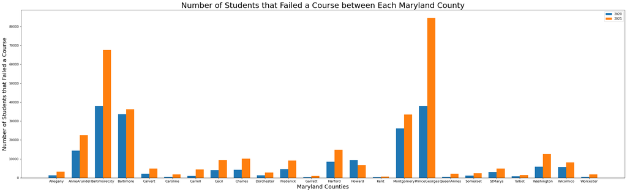

```python
# change size of figures
plt.rcParams["figure.figsize"]=35,10
# make figure and axis
fig, ax = plt.subplots()

# make grouped vertical bar graph
bar_width = 0.35
labels = school_stats_2021.index
index = np.arange(len(labels))
fail_rate_2021 = school_stats_2021['Number_of_Students_Failing_Class'].tolist()
fail_rate_2020 = school_stats_2021['Number_of_Students_Failing_Class_2020'].tolist()

# plot values
ax.bar(index - bar_width/2, fail_rate_2020, bar_width, label = '2020')
ax.bar(index + bar_width/2, fail_rate_2021, bar_width, label = '2021')

# add title and labels
ax.set_xticks(index)
ax.set_xticklabels(labels, fontsize = 11)
ax.set_xlabel('Maryland Counties', fontsize = 18)
ax.set_ylabel('Number of Students that Failed a Course', fontsize = 18)
ax.set_title('Number of Students that Failed a Course between Each Maryland County', fontsize = 25)

# add legend
ax.legend()
```

Blue represents the 2019-2020 school year while orange represents the 2020-2021 school year. Aside from Howard County, we see that the number of students failing a course increases for each county. This teaches us that something drastic happened between these two years to cause this drastic increase in failure rates.

This is a bit difficult to compare between counties since each one has a different amount of students. Instead, let's compare the proportions across counties. Thankfully we already calculated this during our clean-up of the data.

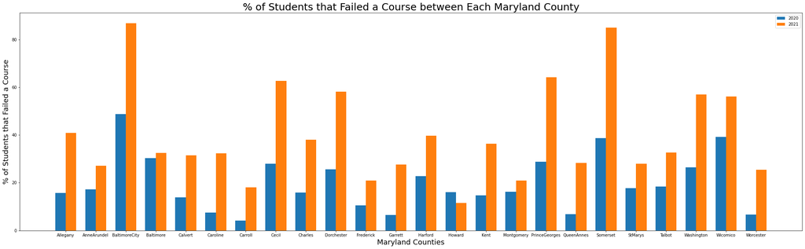

```python
# change size of figures
plt.rcParams["figure.figsize"]=35,10
# make figure and axis
fig, ax = plt.subplots()

# make grouped vertical bar graph
bar_width = 0.35
labels = school_stats_2021.index
index = np.arange(len(labels))
fail_rate_2021 = school_stats_2021['Failed/Students'].tolist()
fail_rate_2020 = school_stats_2021['Failed_2020/Students'].tolist()

# plot values
ax.bar(index - bar_width/2, fail_rate_2020, bar_width, label = '2020')
ax.bar(index + bar_width/2, fail_rate_2021, bar_width, label = '2021')
ax.set_xticks(index)
ax.set_xticklabels(labels)

# add title and labels
ax.set_xlabel('Maryland Counties', fontsize = 18)
ax.set_ylabel('% of Students that Failed a Course', fontsize = 18)
ax.set_title('% of Students that Failed a Course between Each Maryland County', fontsize = 25)

# add legend
ax.legend()
```

### Scatter Plot of % of Failed Courses of Students vs. Covid Cases/Population

As we saw before, there was overall a drastic increase in failures in each county. Mabye the number of COVID cases correlates with this trend. Let's make a scatter plot and see what we see. A scatter plot allows us to view individual points and observe possible trends. instead of other options like a line graph. We also include a line of best fit to clearly display a trend. This can sometimes be misleading however if the trend is not linear.

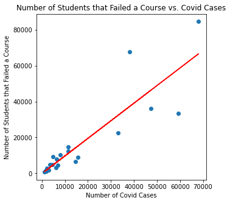

```python
y = school_stats_2021['Number_of_Students_Failing_Class'].tolist()
y_2020 = school_stats_2021['Number_of_Students_Failing_Class_2020'].tolist()
x = school_stats_2021['Covid_Cases'].tolist()

# resize plot to smaller size
plt.rcParams["figure.figsize"]=5,5
fig, ax = plt.subplots()

# create labels
ax.set_xlabel('Number of Covid Cases')
ax.set_ylabel('Number of Students that Failed a Course')
ax.set_title('Number of Students that Failed a Course vs. Covid Cases')

# form scatter plot
ax.scatter(x, y)

# graph linear model
lm = linear_model.LinearRegression()
y_2d = [[num] for num in y]
x_2d = [[num] for num in x]
lm.fit(x_2d, y_2d)
ax.plot(x_2d, lm.predict(x_2d), color = 'red')
```

Very interesting! There seems to be a very strong positive linear correlation between the number of COVID cases and the number of students that failed a course.

*However,* this is way to general. Each county has a different number of students so this data can be a little misleading. Let's fix this by making the values normalized.

As we showed in the bar graphs, the failure rates within each county was drastically different, so making a general statement about these two variables would be very misleading.

Another interesting to point out is that the residual increases as the number of COVID cases increases, making this model most likely not appropriate.

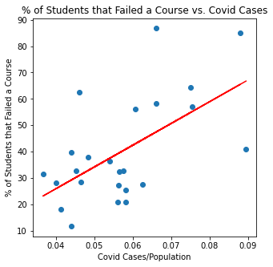

```python
y = school_stats_2021['Failed/Students'].tolist()
y_2020 = school_stats_2021['Failed_2020/Students'].tolist()
x = school_stats_2021['Covid_Cases/Population'].tolist()

# change figure size
plt.rcParams["figure.figsize"]=5,5
fig, ax = plt.subplots()

# title and labels
ax.set_xlabel('Covid Cases/Population')
ax.set_ylabel('% of Students that Failed a Course')
ax.set_title('% of Students that Failed a Course vs. Covid Cases')
ax.scatter(x, y)

# plot linear model
lm = linear_model.LinearRegression()
y_2d = [[num] for num in y]
x_2d = [[num] for num in x]
lm.fit(x_2d, y_2d)
ax.plot(x_2d, lm.predict(x_2d), color = 'red')
```

The trend is not so linear with the normalized data anymore. However, there is a moderate correlation still. A hypothesis would be useful to determine the correlation. Let's also graph the residual plot. A residual is the difference between the actual value minus the predicted value

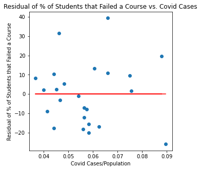

```python
# clear axis
ax.clear()

# title and label
ax.set_xlabel('Covid Cases/Population')
ax.set_ylabel('Residual of % of Students that Failed a Course')
ax.set_title('Residual of % of Students that Failed a Course vs. Covid Cases')

# plot
ax.scatter(x_2d, y_2d - lm.predict(x_2d))
ax.plot(x_2d, [[num*0] for num in x], color = 'red')
fig
```

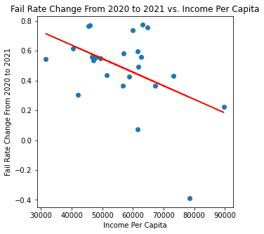

```python
y = school_stats_2021['Fail_Rate_Change'].tolist()
x = school_stats_2021['Income'].tolist()

# plot points
fig, ax = plt.subplots()
ax.scatter(x, y)

# linear model
y_2d = [[num] for num in y]
x_2d = [[num] for num in x]
lm.fit(x_2d, y_2d)
ax.plot(x_2d, lm.predict(x_2d), color = 'red')

# title and axis labels
ax.set_xlabel('Income Per Capita')
ax.set_ylabel('Fail Rate Change From 2020 to 2021')
ax.set_title('Fail Rate Change From 2020 to 2021 vs. Income Per Capita')
```

There is a moderate negative linear trend between the fail rate change and income per capita. Let's also graph the residual plot.

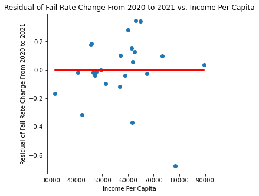

```python
# clear plot
ax.clear()

# title and label
ax.set_xlabel('Income Per Capita')
ax.set_ylabel('Residual of Fail Rate Change From 2020 to 2021')
ax.set_title('Residual of Fail Rate Change From 2020 to 2021 vs. Income Per Capita')

# plot
ax.scatter(x_2d, y_2d - lm.predict(x_2d))
ax.plot(x_2d, [[num*0] for num in x], color = 'red')
fig
```

## Hypothesis Testing

Let's first determine if there is a *significant* increase in number of students failing a course between 2020 and 2021. In order to compare the values between counties, we must used the normalized values.

```python
y = school_stats_2021['Failed/Students'].tolist()
y_2020 = school_stats_2021['Failed_2020/Students'].tolist()
stats.ttest_ind(y_2020, y)
```

```
Ttest_indResult(statistic=-4.2792395680335495, pvalue=9.403797271395658e-05)
```

The p-value is much less than 0.05. Therefore we can reject the null hypothesis and conclude that there is significant difference in failure rates between 2020 and 2021.

```python
y = school_stats_2021['Failed/Students'].tolist()
x = school_stats_2021['Covid_Cases/Population'].tolist()
stat, p = pearsonr(x, y)
p
```

```
0.0027965119446575998
```

Our p-value is 0.0028 which is far less than 0.05. Therefore we can reject the null hypothesis, and we can conclude that the two variables are dependent.

To see if there is a significant correlation between the fail rate change and income per capita. We can use the Pearson correlation coefficient.

The null hypothesis is that the fail rate change and income per capita are independent (i.e. one changeing in value does not affect the other). The alternative hypothesis is that there is some dependency between the variables. If the p-value is less than 0.05, we can reject the null hypothesis.

```python
y = school_stats_2021['Fail_Rate_Change'].tolist()
x = school_stats_2021['Income'].tolist()
stat, p = pearsonr(x, y)
p
```

```
0.02399942768770839
```

The p-value is less than 0.05. We can reject the null hypothesis and conclude that there is depencency between the Fail Rate change and income per capita.

## Insight and Conclusions

There were many insightful trends that we found in our analysis.

### Linear Correlation Between Failure Rates and COVID Cases/Population

From our scatter plot, we found a moderate positive correlation between these two variables. After calculating the Pearson correlation coefficient, we were able to conclude that there is a linear correlation between the failure rate and COVID cases/population. As COVID cases increase, the failure rate of student also increases. This makes sense as the virus can physically and mentally damage an individual and people around them. If a student or a close person to a student was infected. They would have to priortize their health over the academic duties. However, future studies would need to be conducted to validate these speculations

### Linear Correlation Between Failure Rates Change and Income Per Capita

Looking at the group vertical bar graph, I noticed that a the biggest increases in failure rates were found in counties with low incomes per capita. After making a scatter plot, we found a moderate negative correlation. After calculating the Pearson correlation coefficient, we were able to conclude that there is a negative linear correlation between the failure rate change and income per capita. As the income per capita increase, the failure rate of student decreases. This makes total sense as wealthier familiies are able to buy resources that allow their children (students) to be more prepared to school, leading to lower failure rates. However, this correlation shows that wealthier families were less impacted academically between two years. This might be because wealthier families have much more disposable income are able to prioritize their health/academic duties unlike impoverished families that have to continue working. It's also worth noting that higher paying jobs are able to be performed at home virtually while many lower paying jobs like the food service industry must be performed in-person. This in turn increases the chance to be exposed to the virus for people working in these jobs, thus placing more stress on their families. Future studies would need to be conducted to validate these speculations

## Future Studies

While these are promising results, there is further analysis that can be conducted. Due to the time restriction of the course, I was unable to conduct topics like these:

Why COVID cases correlate to increased failure rates?

Does the county government spending on education affect this?

Are minority groups affected more by COVID regards to academic performance?

## Resources

Use these sources to learn about the libraries used

[Pandas](https://pandas.pydata.org/)

[NumPy](https://numpy.org/)

[MatplotLib](https://matplotlib.org/)

[SciKit Learn](https://scikit-learn.org/stable/)

[CSV](https://docs.python.org/3/library/csv.html)

[DateTime](https://docs.python.org/3/library/datetime.html)

[SciPy](https://www.scipy.org/)

Here are links to the .csv files used

school_stats_.csv

covid_cases.csv

mdpop.csv

Enrollment.csv

income.csv

### Final Remarks

As of the date this is published, the COVID-19 pandemic is still rampant despite mass vaccinations. Please make sure to wear masks when necessary and wash your hand often. For more information about the pandemic, please visit the CDC website for more information.

P.S. This research has not been peer reviewed. Please to refer to other reliable resources as well for more information.